# Mini-version of project (to test that things run)

Emma Skarstein

October 2020

```r
library(ggplot2)
library(sf) # for sf objects
library(plyr)
library(dplyr) # for smoother dataframe-manipulation
library(here) # for cleaner filepath-handling
library(ggmap) # also for nice maps
library(maps)
library(RColorBrewer)
library(INLA)
library(PointedSDMs)
library(sp)
library(spatstat)
library(maptools)
library(reshape2)
library(rgeos)
library(fields)
library(viridis)
library(colorspace)
library(patchwork)
```

## Introduction

This file runs all the code necessary to recreate the final model proposed in my master’s thesis, [“Accounting for spatial bias in citizen science observations of Norwegian freshwater fish by using an effort spatial field”](https://github.com/emmaSkarstein/Citizen_Science_Skarstein_master/blob/master/thesis.pdf). I have included all species observations and covariates in the repository.

Note that this file only covers the final model of my thesis, a large part of the work in the thesis was evaluating and comparing different models on different fish species, but this has been omitted for now because the cross-validation procedure used is very time-consuming.

## Downloading necessary data

I have uploaded all the cleaned data to the “data”-folder, except for the lake polygons which are too large to include on Github. But they are easily available here:

- **Lake polygons for Norway:** Go to https://bird.unit.no/resources/9b27e8f0-55dd-442c-be73-26781dad94c8/content (click on “Innhold”-tab at the bottom of the page to download only selected sets of lakes). The object name should be Norwegian_lakes.rds, and it should be placed in a “data” folder on the top level (the same level as the R-project).

## Loading Norway map

```r
# MAP ---------------------------------------------------------------------------------------------------------
norway <- ggplot2::map_data("world", region = "Norway(?!:Svalbard)")
norway <- setdiff(norway, filter(norway, subregion == "Jan Mayen"))
Projection <- CRS("+proj=longlat +ellps=WGS84")
norwayfill <- map("world", "norway", fill=TRUE, plot=FALSE,
                  ylim=c(58,72), xlim=c(4,32))
IDs <- sapply(strsplit(norwayfill$names, ":"), function(x) x[1])
norway.poly <- map2SpatialPolygons(norwayfill, IDs = IDs,
                                   proj4string = Projection)
```

## Setting up observation and environmental data

Next we load the observations as well as the environmental data.

```r
# LOADING DATA AND COVARIATES ---------------------------------------------------------------------------------

# Covariates
covariateData <- readRDS("../data/environmental_covariates.RDS")
covariateData <- covariateData[complete.cases(covariateData$decimalLatitude,
                                              covariateData$decimalLongitude,
                                              covariateData$area_km2,
                                              covariateData$HFP),]
covariateData <- covariateData %>% mutate(log_area = log(area_km2)) %>%
  select(-c(ebint, no_vatn_lnr, eb_waterregionID))

head(covariateData)
```

```
##   waterBodyID decimalLatitude decimalLongitude   area_km2 perimeter_m
## 1     3531617        64.30199        11.049305 0.15370997        3492
## 2     3531112        63.73470        10.680250 0.13366573        2349
## 3     2877565        59.04880         7.863702 0.11454878        1632
## 4     3355832        60.23034         6.427800 0.01008058         486
## 5     2695076        59.58998        11.470182 0.01569860         642
## 6     3311288        58.08718         7.331050 0.01509316         835
##   distance_to_road eurolst_bio10 catchment_area_km2      SCI       HFP
## 1             5681     127.89760             0.7603 1.144443  1.439096
## 2             1501     121.96890             0.9819 1.534130  4.071300
## 3             3602     124.03020             1.9025 1.774869  5.000000
## 4              156      95.41962             0.4089 1.416126  2.775584
## 5              905     135.03910             7.5086 1.554206 11.527012
## 6              701     141.01520             0.4762 1.573568 12.144801
##    log_area
## 1 -1.872688
## 2 -2.012413
## 3 -2.166755
## 4 -4.597145
## 5 -4.154184
## 6 -4.193514
```

```r
# Choose from
# "decimalLatitude", "decimalLongitude",
# "area_km2", "perimeter_m", "distance_to_road",
# "eurolst_bio10", "catchment_area_km2", "SCI", "HFP"
Use <- c("decimalLongitude","decimalLatitude", "log_area", #"perimeter_m",
         "eurolst_bio10", "SCI")

Covariates <- SpatialPointsDataFrame(coords = covariateData[,c("decimalLongitude","decimalLatitude")],
                                     data = covariateData[,Use],
                                     proj4string = Projection)
#Covariates@data <- data.frame(apply(Covariates@data, 2, scale))  # scale the covariates

# Observations
Data_survey_df <- readRDS("../data/survey_clean.rds")
Data_survey <- SpatialPointsDataFrame(coords = Data_survey_df[,c("decimalLongitude","decimalLatitude")],
                                      data = Data_survey_df[,c("occurrenceStatus","species")],
                                      proj4string = Projection)

Data_artsobs_df <- readRDS("../data/artsobs_clean.rds")
Data_artsobs <- SpatialPointsDataFrame(coords = Data_artsobs_df[,c("decimalLongitude","decimalLatitude")],
                                       data = Data_artsobs_df[,c("occurrenceStatus","species")],
                                       proj4string = Projection)



# Separating by species:
perch_survey_df <- filter(Data_survey_df, grepl('Perca fluviatilis', species))
trout_survey_df <- filter(Data_survey_df, grepl('Salmo trutta', species))
char_survey_df <- filter(Data_survey_df, grepl('Salvelinus alpinus', species))
pike_survey_df <- filter(Data_survey_df, grepl('Esox lucius', species))

perch_artsobs_df <- filter(Data_artsobs_df, grepl('Perca fluviatilis', species))
trout_artsobs_df <- filter(Data_artsobs_df, grepl('Salmo trutta', species))
char_artsobs_df <- filter(Data_artsobs_df, grepl('Salvelinus alpinus', species))
pike_artsobs_df <- filter(Data_artsobs_df, grepl('Esox lucius', species))


MakeSpDF <- function(df){
  Projection <- CRS("+proj=longlat +ellps=WGS84")
  sp_df <- SpatialPointsDataFrame(coords = df[,c("decimalLongitude","decimalLatitude")],
                                  data = df[,c("occurrenceStatus","species")],
                                  proj4string = Projection)
  sp_df
}

perch_survey <- MakeSpDF(perch_survey_df)
trout_survey <- MakeSpDF(trout_survey_df)
char_survey <- MakeSpDF(char_survey_df)
pike_survey <- MakeSpDF(pike_survey_df)

perch_artsobs <- MakeSpDF(perch_artsobs_df)
trout_artsobs <- MakeSpDF(trout_artsobs_df)
char_artsobs <- MakeSpDF(char_artsobs_df)
pike_artsobs <- MakeSpDF(pike_artsobs_df)
```

Now we have the covariates in ‘Covariates’, as well as two types of data sets in ‘Data_survey’ and ‘Data_artsobs’.

## Stacks!

### Integration stack

The integration stack gives the points in the INLA mesh. We first create this mesh from the Norway-polygon-object:

```r
# INTEGRATION STACK --------------------------------------------------------------------------------------------
Meshpars <- list(cutoff=0.08, max.edge=c(0.6, 3), offset=c(1,1))
Mesh <- MakeSpatialRegion(data=NULL, bdry=norway.poly, meshpars=Meshpars,
                          proj = Projection)
#plot(Mesh$mesh)
```

And then we can create the actual integration stack:

```r
stk.ip <- MakeIntegrationStack(mesh=Mesh$mesh, data=Covariates,
                               area=Mesh$w, tag='ip', InclCoords=TRUE)
```

### Stack for survey data (structured)

The stack for the structured survey data is made the same way as before, nothing changes here. This corresponds to the predictor

$$\hat\alpha_{PA} + \hat\beta_{x}(s) + \hat\xi_1(s),$$
where $\alpha_{PA}$ is the intercept, $\hat\beta_{x}(s)$ is the estimated environmental field and $\hat\xi_1(s)$ is the estimated spatial field.

```r
# SURVEY, STRUCTURED STACK ---------------------------------------------------------------------------------------------
stk.survey <- MakeBinomStack(observs = trout_survey, data = Covariates,
                             mesh=Mesh$mesh, presname="occurrenceStatus",
                             tag="survey", InclCoords=TRUE)
# Note that when using 'MakeBinomStack' here, the spatial effect in stk.survey is just called "i",
#  while in the unstructured data stack we called the corresponding effect 'shared_field'.
```

### Stack for citizen science data (unstructured)

When we get to the unstructured citizen science data, this is where things start to change. Since we want to add a second spatial field here, we can no longer use the function ‘MakePointsStack()’ from the ‘PointedSDM’ package. This now corresponds to the predictor
$$\hat\alpha_{PO} + \hat\beta_{x}(s) + \hat\xi_1(s) + \hat\xi_2(s).$$
Note that we now have a different intercept, but the environmental and first spatial field are the same as for the structured data. Then at last we have the second estimated spatial field, $\hat\xi_2(s)$.

```r
# ARTSOBS, UNSTRUCTURED STACK -------------------------------------------------------------------------------------------
# Finding the covariates that are closest to the observation points
NearestCovs_unstr <- GetNearestCovariate(points = trout_artsobs, covs = Covariates)
NearestCovs_unstr@data[ , "int.artsobs"] <- 1 # add intercept

# Projector matrix from mesh to unstructured data
projmat.artsobs <- inla.spde.make.A(mesh = Mesh$mesh,
                                    loc = as.matrix(trout_artsobs@coords))

stk.artsobs <- inla.stack(data = list(resp = cbind(rep(1,nrow(NearestCovs_unstr)), NA),
                                              e = rep(0, nrow(NearestCovs_unstr))),
                                    A = list(1, projmat.artsobs),
                                    tag = "artsobs",
                                    effects = list(NearestCovs_unstr@data,
                                                 list(shared_field = 1:Mesh$mesh$n,
                                                      bias_field = 1:Mesh$mesh$n))) # This is for the second spatial field!
```

### Prediction stack

In order to do predictions we make a prediction stack, just the same as before.

```r
# PREDICTIONS ----------------------------------------------------------------------------------------------------------
Nxy.scale <- 0.1 # use this to change the resolution of the predictions
Nxy <- round(c(diff(norway.poly@bbox[1,]), diff(norway.poly@bbox[2,]))/Nxy.scale)
stk.pred <- MakeProjectionGrid(nxy=Nxy, mesh=Mesh$mesh, data=Covariates,
                               tag='pred',boundary=norway.poly)
```

## Fitting the model

Then finally we get to the model fitting. Here we need to change the formula to include the second spatial field.

```r
# CONSTRUCTING FORMULA -------------------------------------------------------------------------------------------------

# First specifying the formula components
intercepts <- "int.survey + int.artsobs - 1"
env_effects <- paste(Use, collapse = ' + ')
spatial_effects <- "f(shared_field, model = mesh.shared) +
                    f(i, copy = 'shared_field') +
                    f(bias_field, model = mesh.bias)"

Formula <- as.formula(paste(c("resp ~ 0 ", intercepts, env_effects, spatial_effects),
                            collapse = " + "))
```

We create the spde-thingy for each of the spatial fields:

```r
mesh.shared <- INLA::inla.spde2.pcmatern(Mesh$mesh,
                                         prior.range = c(10, 0.1),
                                         #prior.sigma = c(0.5, 0.1)
                                         prior.sigma = c(0.1, 0.1)
                                           )
mesh.bias <- INLA::inla.spde2.pcmatern(Mesh$mesh,
                                       prior.range = c(10, 0.1),
                                       prior.sigma = c(0.1, 0.1))
```

These factor into the final model through the formula:

```r
Formula
```

```
## resp ~ 0 + int.survey + int.artsobs - 1 + decimalLongitude +
##     decimalLatitude + log_area + eurolst_bio10 + SCI + f(shared_field,
##     model = mesh.shared) + f(i, copy = "shared_field") + f(bias_field,
##     model = mesh.bias)
```

We then fit the model:

```r
# FITTING MODEL -------------------------------------------------------------------------
stck <- inla.stack(stk.survey, stk.artsobs, stk.ip, stk.pred$stk)

# Fit model including predictions
mod <- INLA::inla(Formula, family=c('poisson','binomial'),
            control.family = list(list(link = "log"), list(link = "cloglog")),
            data=inla.stack.data(stck), verbose=FALSE,
            control.results=list(return.marginals.random=FALSE,
                                 return.marginals.predictor=FALSE),
            control.predictor=list(A=inla.stack.A(stck), link=NULL, compute=TRUE),
            control.fixed = list(mean=0),
            Ntrials=inla.stack.data(stck)$Ntrials, E=inla.stack.data(stck)$e,
            control.compute=list(waic=FALSE, dic=FALSE))

# For predictions
id <- inla.stack.index(stck, "pred")$data
pred <- data.frame(mean=mod$summary.fitted.values$mean[id],
                  stddev=mod$summary.fitted.values$sd[id])

model_output <- list(model = mod, predictions = pred)
```

## Results

Looking at the summary of the model:

```r
summary(model_output$model)
```

```
##
## Call:
##    c("INLA::inla(formula = Formula, family = c(\"poisson\", \"binomial\"),
##    ", " data = inla.stack.data(stck), E = inla.stack.data(stck)$e, ", "
##    Ntrials = inla.stack.data(stck)$Ntrials, verbose = FALSE, ", "
##    control.compute = list(waic = FALSE, dic = FALSE), control.predictor =
##    list(A = inla.stack.A(stck), ", " link = NULL, compute = TRUE),
##    control.family = list(list(link = \"log\"), ", " list(link =
##    \"cloglog\")), control.results = list(return.marginals.random = FALSE,
##    ", " return.marginals.predictor = FALSE), control.fixed = list(mean =
##    0))" )
## Time used:
##     Pre = 5.55, Running = 511, Post = 0.451, Total = 517
## Fixed effects:
##                    mean    sd 0.025quant 0.5quant 0.975quant   mode kld
## int.survey        0.411 0.035      0.343    0.411      0.478  0.411   0
## int.artsobs       0.844 0.059      0.728    0.844      0.960  0.844   0
## decimalLongitude -0.001 0.002     -0.005   -0.001      0.003 -0.001   0
## decimalLatitude   0.000 0.001     -0.002    0.000      0.002  0.000   0
## log_area          0.001 0.007     -0.013    0.001      0.015  0.001   0
## eurolst_bio10     0.000 0.000     -0.001    0.000      0.001  0.000   0
## SCI               0.003 0.030     -0.056    0.003      0.062  0.003   0
##
## Random effects:
##   Name     Model
##     shared_field SPDE2 model
##    bias_field SPDE2 model
##    i Copy
##
## Model hyperparameters:
##                          mean    sd 0.025quant 0.5quant 0.975quant   mode
## Range for shared_field 12.841 6.632      4.822   11.262     29.894  8.882
## Stdev for shared_field  0.033 0.014      0.013    0.030      0.067  0.025
## Range for bias_field   11.130 2.284      7.385   10.872     16.322 10.359
## Stdev for bias_field    0.514 0.078      0.379    0.508      0.685  0.496
##
## Expected number of effective parameters(stdev): 23.45(2.53)
## Number of equivalent replicates : 163.26
##
## Marginal log-Likelihood:  208.69
## Posterior marginals for the linear predictor and
##  the fitted values are computed
```

For the plots I use some functions found in the file Model_visualization_functions.R.

We can plot the effort field $\hat\xi_2(s)$ and the shared spatial field $\hat\xi_1(s)$ as follows:

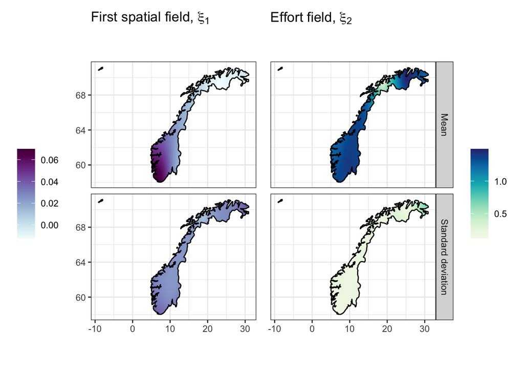

```r
spat_fields_df <- proj_random_field(model_output$model, sp_polygon = norway.poly,
                                    mesh = Mesh$mesh)
spat_fields <- spat_fields_df %>% tidyr::gather(key = statistic, value = value, mean:sd)

# New labels for statistics variable
statistic.labs <- c("Mean", "Standard deviation")
names(statistic.labs) <- c("mean", "sd")

# New labels for field variable
field.labs <- c("Second spatial field (PO data only)", "First spatial field (both data sets)")
names(field.labs) <- c("bias", "shared")

shared_p <- ggplot(spat_fields %>% filter(field == "shared")) +
  geom_raster(aes(x = decimalLongitude, y = decimalLatitude, fill = value)) +
  #scale_fill_viridis(option = "magma", direction = -1) +
  scale_fill_continuous_sequential(palette = "BuPu")  +
  facet_grid(rows = vars(statistic),
             labeller = labeller(field = field.labs, statistic = statistic.labs)) +
  geom_polygon(data = norway, aes(long, lat, group = group),
               color="black", fill = NA) + coord_quickmap() +
  theme_bw() +
  theme(axis.title = element_blank(), legend.position = "left",
        strip.background = element_blank(), strip.text.y = element_blank(),
        legend.title = element_blank()) +
  ggtitle(expression(paste("First spatial field, ", xi[1])))

bias_p <- ggplot(spat_fields%>% filter(field == "bias")) +
  geom_raster(aes(x = decimalLongitude, y = decimalLatitude, fill = value)) +
  #scale_fill_viridis(option = "viridis", direction = -1) +
  scale_fill_continuous_sequential(palette = "GnBu")  +
  facet_grid(rows = vars(statistic),
             labeller = labeller(field = field.labs, statistic = statistic.labs)) +
  geom_polygon(data = norway, aes(long, lat, group = group),
               color="black", fill = NA) + coord_quickmap() +
  theme_bw() +
  theme(axis.title = element_blank(), axis.ticks.y = element_blank(),
        axis.text.y = element_blank(), legend.title = element_blank()) +
  ggtitle(expression(paste("Effort field, ", xi[2])))

shared_p + bias_p
```

We can plot the predictions:

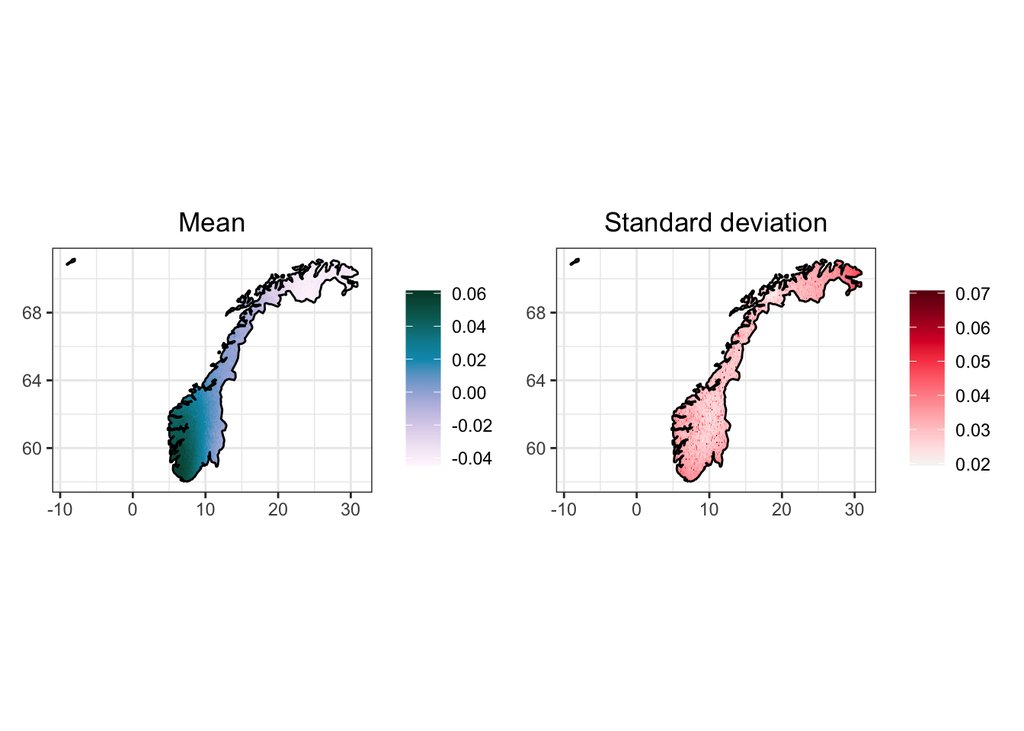

```r
Pred <- prediction_df(stk.pred = stk.pred, model = model_output)
Pred_mean <- Pred %>% filter(statistic=="mean")
Pred_sd <- Pred %>% filter(statistic=="stddev")
p_mean <- ggplot(Pred_mean) +
  geom_raster(aes(x = decimalLongitude, y = decimalLatitude, fill = value)) +
  scale_fill_continuous_sequential(palette = "PuBuGn")  +
  geom_polygon(data = norway, aes(long, lat, group = group),
               color='black', fill = NA) + coord_quickmap() +
  ggtitle(label = "Mean") +
  labs(fill = element_blank()) +
  theme_bw() + theme(axis.title = element_blank(), plot.title = element_text(hjust = 0.5))

p_sd <- ggplot(Pred_sd) +
  geom_raster(aes(x = decimalLongitude, y = decimalLatitude, fill = value)) +
  scale_fill_continuous_sequential(palette = "Reds 3")  +
  geom_polygon(data = norway, aes(long, lat, group = group),
               color='black', fill = NA) + coord_quickmap() +
  ggtitle(label = "Standard deviation") +
  labs(fill = element_blank()) +
  theme_bw() + theme(axis.title = element_blank(), plot.title = element_text(hjust = 0.5))

p_mean + p_sd
```